# Financial Analysis of PEGA and CRM

## Author: Aidan Irish

## Date: 11/19/2017

## Introduction

Pegasystems (PEGA) and Salesforce (CRM) are software developing companies that make applications for marketing, sales, service, and operations. Pegasystems has a strong focus on customer relationship management applications and giving clients the tools to build their own applications. Salesforce has a similar focus, but the company offers more services in the cloud. The customer base for these companies includes a wide range of firms and individuals: the sales teams are regularly competing for the same future clients.

# Import Data

```python
import numpy as np
import pandas as pd
```

```python
pega = pd.read_csv("pega.csv", index_col="figures")
#Transpose
pega = pega.T
pega
```

| figures | SalesGrowth | ChangeInNI | ChangeInLongTermDebt | TotalDebtRatio | DebtEquityRatio | EquityMultiplier | ProfitMargin | ROA | ROE | ReceivablesTurnover | TotalAssetTurnover |
| --- | --- | --- | --- | --- | --- | --- | --- | --- | --- | --- | --- |
| 2012 | 0.11 | 1.16 | NaN | 0.46 | 0.86 | 1.86 | 0.05 | 0.05 | 0.09 | 3.29 | 1.05 |
| 2013 | 0.10 | 0.74 | NaN | 0.49 | 0.96 | 1.96 | 0.07 | 0.07 | 0.14 | 2.99 | 0.95 |
| 2014 | 0.16 | -0.13 | NaN | 0.50 | 0.99 | 1.99 | 0.06 | 0.06 | 0.11 | 3.70 | 1.00 |
| 2015 | 0.16 | 0.09 | NaN | 0.49 | 0.94 | 1.94 | 0.05 | 0.06 | 0.11 | 3.15 | 1.09 |
| 2016 | 0.10 | -0.26 | NaN | 0.50 | 1.00 | 2.00 | 0.04 | 0.04 | 0.08 | 2.69 | 1.12 |

```python
crm = pd.read_csv("crm.csv", index_col="figures")
#Transpose
crm = crm.T
crm
```

| figures | SalesGrowth | ChangeInNI | ChangeInLongTermDebt | TotalDebtRatio | DebtEquityRatio | EquityMultiplier | ProfitMargin | ROA | ROE | ReceivablesTurnover | TotalAssetTurnover |
| --- | --- | --- | --- | --- | --- | --- | --- | --- | --- | --- | --- |
| 2012 | 0.35 | -39.28 | 0.08 | 0.57 | 1.32 | 2.32 | -0.09 | -0.05 | -0.12 | 4.14 | 0.57 |
| 2013 | 0.33 | 0.24 | 12.78 | 0.66 | 1.94 | 2.94 | -0.05 | -0.02 | -0.07 | 3.31 | 0.45 |
| 2014 | 0.33 | -0.40 | 0.12 | 0.62 | 1.62 | 2.62 | -0.05 | -0.03 | -0.07 | 3.39 | 0.51 |
| 2015 | 0.24 | 0.78 | -0.07 | 0.60 | 1.47 | 2.47 | -0.01 | -0.01 | -0.01 | 3.19 | 0.54 |
| 2016 | 0.26 | 4.09 | 0.13 | 0.56 | 1.27 | 2.27 | 0.02 | 0.01 | 0.03 | 3.18 | 0.50 |

```python
snap = pd.read_csv("snapshot.csv", index_col="figures")
#Transpose
snap = snap.T
snap
```

| figures | market cap | price/book value | enterprise value | eps | pe | ebitda | evebitda |
| --- | --- | --- | --- | --- | --- | --- | --- |
| crm | 7.808200e+10 | 9.3 | 7.145000e+10 | -0.11 | 66.70 | 464080000.0 | 153.960524 |
| pega | 4.009000e+09 | 11.1 | 4.280000e+09 | 0.62 | 82.64 | 75150000.0 | 56.952761 |

### Visualization Package Installation

```python
import matplotlib.pyplot as plt
%matplotlib inline
```

# Growth Analysis

To dial in on how how viable a company is in terms or revenue and earnings, it is critical to anaylze sales and net income data. Determining whether or not a company is able to produce growth and stability in sales and net income speaks to the value and future of the entire organization.

## Sales Growth

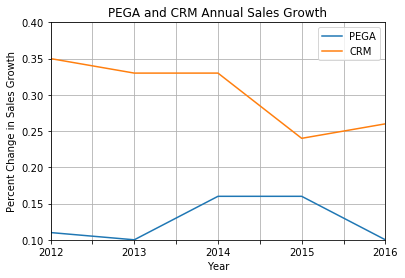

```
Average PEGA Sales Growth: 0.126
Average CRM Sales Growth: 0.302
```

```python
psg = pega.SalesGrowth.plot()
csg = crm.SalesGrowth.plot(grid="on", title="PEGA and CRM Annual Sales Growth")
csg.set_ylim(0.10,0.40)
plt.xlabel("Year")
plt.ylabel("Percent Change in Sales Growth")
plt.legend(["PEGA", "CRM"]);
plt.show()

print('Average PEGA Sales Growth: ' + str(np.mean(pega.SalesGrowth)))
print('Average CRM Sales Growth: ' + str(np.mean(crm.SalesGrowth)))
```

While both companies have been increasing revenue annually, Saleforce appears to be reaching new, significant highs year after year. Over the past five years, Saleforce has seen an averge of 30% annual sales growth and Pegesystems has averaged at about 13%.

## Change in Net Income

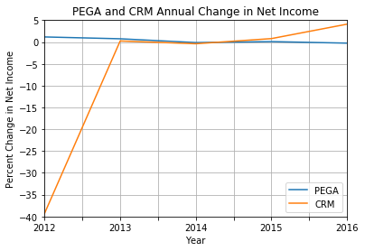

```python
pni = pega.ChangeInNI.plot()
cni = crm.ChangeInNI.plot(grid="on", title="PEGA and CRM Annual Change in Net Income")
cni.set_ylim(-40,5)
plt.xlabel("Year")
plt.ylabel("Percent Change in Net Income")
plt.legend(["PEGA", "CRM"]);
plt.show()
```

# Debt and Leverage Analysis

Analyzing leverage ratios is a way to asses each company’s ability to pay off debt. All companies have financial obligations, and how comfortably a company can pay for debts says a lot about its financial health. The inability to meet these obligations can result in selling assets or declaring bankruptcy.

## Total Debt Ratio

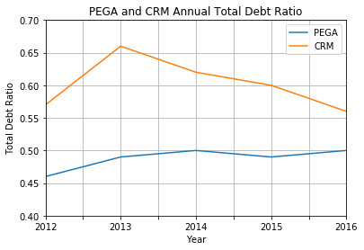

```python
ptd = pega.TotalDebtRatio.plot()
ctd = crm.TotalDebtRatio.plot(grid="on", title="PEGA and CRM Annual Total Debt Ratio")
ctd.set_ylim(0.4,0.7)
plt.xlabel("Year")
plt.ylabel("Total Debt Ratio")
plt.legend(["PEGA", "CRM"]);
plt.show()
```

The graph shows Saleforce well above Pegasystems in terms of leverage. Showing a total debt ratio greater than 0.5 is concerning because that means a company operates with debt thats more than half the size of its assets.

## Debt Equity Ratio

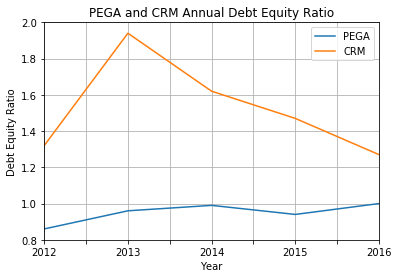

[output not shown]

```python
pde = pega.DebtEquityRatio.plot()
cde = crm.DebtEquityRatio.plot(grid="on", title="PEGA and CRM Annual Debt Equity Ratio")
cde.set_ylim(0.8,2.0)
plt.xlabel("Year")
plt.ylabel("Debt Equity Ratio")
plt.legend(["PEGA", "CRM"]);
plt.show()

print('Average PEGA Debt Equity: ' + str(np.mean(pega.DebtEquityRatio)))
print('Average CRM Debt Equity: ' + str(np.mean(crm.DebtEquityRatio)))
```

Over the past five years, Pega has had an average 95 cents of debt for every $1 of equity, while Salesforce is at $1.52. This puts Salesforce at a disadvantage because of the possible consequences of debt.

## Change in Long-Term Debt

#### PEGA LTD is not reported on financials

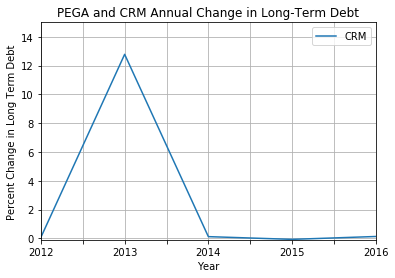

```python
cltd = crm.ChangeInLongTermDebt.plot(grid="on", title="PEGA and CRM Annual Change in Long-Term Debt")
cltd.set_ylim(-0.1,15)
plt.xlabel("Year")
plt.ylabel("Percent Change in Long Term Debt")
plt.legend(["CRM"]);
plt.show()
```

It becomes clear why Saleforce's total debt and debt equity ratios saw a large increase in 2013. It appears that Salesforce took on a large increase to debt in 2013. Looking at the total debt and debt equity ratios over the last three years, Saleforce is slowly decreasing its liabilities and becoming less leveraged.

# Profitability Anaylsis

By analyzing the profitability ratios of Pegasystems and Salesforce, we can see a clear leader in how efficiently the company manages its assets and operations. The higher the figure in these ratios, the higher the earnings relative to expenses and other costs.

## Net Profit Margin

[figure not shown]

```python
ppm = pega.ProfitMargin.plot()
cpm = crm.ProfitMargin.plot(grid="on", title="PEGA and CRM Annual Net Profit Margin")
cpm.set_ylim(-0.20,0.20)
plt.xlabel("Year")
plt.ylabel("Net Profit Margin")
plt.legend(["PEGA", "CRM"]);
plt.show()
```

For Pega, the net profit margin in the last 5 years peaked at 7% in 2013 but is currently at 4%. Salesforce was down at -9% in 2012 but has recently resurfaced to 2%. The negative margins suggest that Salesforce was losing money from selling, but possibly making up losses with a higher volume of sales. Pega’s ability to earn a profit is uniform and Salesforce is slowly catching up.

# ROE and ROA

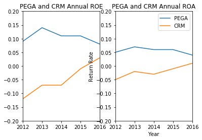

```python
fig, axs = plt.subplots(1,2)

proe = pega.ROE.plot(ax=axs[0], title="PEGA and CRM Annual ROE")
croe = crm.ROE.plot(ax=axs[0])


proa = pega.ROA.plot(ax=axs[1], title="PEGA and CRM Annual ROA")
croa = crm.ROA.plot(ax=axs[1])
proa.set_ylim(-0.20,0.20)
proe.set_ylim(-0.20,0.20)
plt.xlabel("Year")
plt.ylabel("Return Rate")
plt.legend(["PEGA", "CRM"]);
plt.show()
```

Pegasystems is keeping a higher percentage of its earnings over equity and assets. Being able to produce postive ROA and ROE consistently show that a company is efficient and in good financial health.

# Size and Profitability

## Company Size

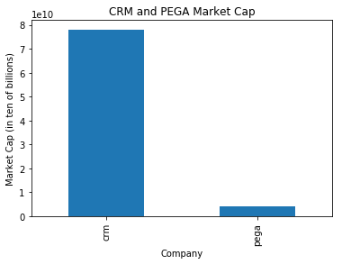

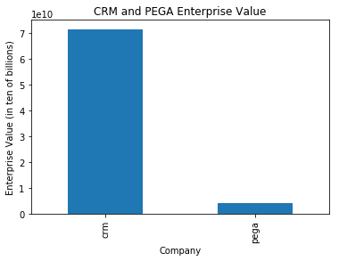

```python
pmc = snap.marketcap.plot(kind="bar", title="CRM and PEGA Market Cap")

plt.xlabel("Company")
plt.ylabel("Market Cap (in ten of billions)")
plt.show()

pev = snap.enterprisevalue.plot(kind="bar", title="CRM and PEGA Enterprise Value")

plt.xlabel("Company")
plt.ylabel("Enterprise Value (in ten of billions)")
plt.show()
```

Salesforce is much larger in both market cap and enterprise value. When comparing these companies based on ratios, some of the figures are so similar, it's suprising to see how massive one is compared to the other. All finances at Salesforce are run at much higher capacity.

## Profitability Measures

### Earning Per Share

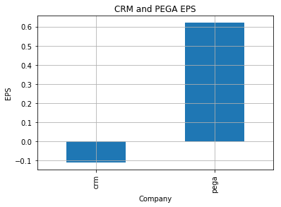

```python
peps = snap.eps.plot(kind="bar", title="CRM and PEGA EPS", grid=True)

plt.xlabel("Company")
plt.ylabel("EPS")
plt.show()
```

### PE and Enterprise Value/EBITDA

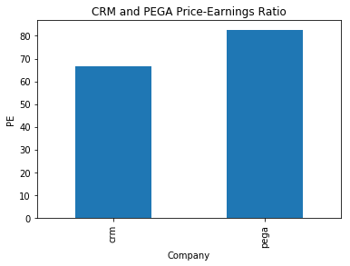

```python
ppe = snap.pe.plot(kind="bar", title="CRM and PEGA Price-Earnings Ratio")

plt.xlabel("Company")
plt.ylabel("PE")
plt.show()
```

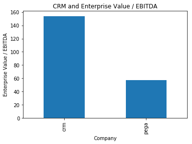

```python
peve = snap.evebitda.plot(kind="bar", title="CRM and Enterprise Value / EBITDA")

plt.xlabel("Company")
plt.ylabel("Enterprise Value / EBITDA")
plt.show()
```

According tot the PE ratio, investers have a lot of faith in the futures of Salesforce and Pegasystems. Investors are willing to pay about $82 for $1 of Pegasystems earnings and $66 for Salesforce. Salesforce has a suprisingly high PE considering the company currently has a negative EPS of -0.11 and very high Enterprise Value/EBITDA ratio.

# Conclusion

In the last five years, both Salesforce and Pegasystems have improved their financial health. Even though these two companies are very different in size, these ratios give an insight into their financials. Pega proves to be the more mature company. Pega is doing very well based on not being highly-leveraged and consistently reporting positive returns on assets and equity. However, Salesforce isn’t too far behind: financials reported in 2016 show the company improving quickly with a 409% boost in net income.